# Waffles vs Pies

Rafael Cruz Gil, Sushmita Gopalan, Beau Harrison, Rodrigo Valdés

4 May 2018

### Introduction

This experiment has as its main goal to compare how different visualisation strategies affect perception of proportions. To do so, two different types of charts will be used, pie charts and waffle charts. Since pie charts are notoriously hard to read (Cairo, 2016), this should provide an interesting exercise. However, since it is one of the most familiar plots (idem), it is also one that should be given attention and have its functionality questioned.

To get the users to focus solely on the proportions, we used made-up data about preferences for ice cream flavours, since this should prove uncontroversial. To provide some variation, flavours and proportions vary along the experiment, but are overall consistent. The questions were prepared in Qualtrics and randomisation was used to set up the questions. A timer of 15 seconds per question was also set up, but it did not work as intended.

In order to explore this issue to the fullest, we shall also try to determine whether order and colour have an effect on the perception of proportion. To do so, the order in which the flavours are presented will be altered, as well as the colours for the flavours themselves. While they usually are labeled according to a colour that would be easily associated with the flavour, for some questions some (or all) will be mislabeled.

The survey ran for 5 days and a total of 210 surveys were considered for this analysis.

### Methodology

We set up five experiments to test waffle and pie charts in five different situations. The main question behind these experiments was to find out which of the two graphs provides the most accurate information, defined as the deviation of the real data to the perception of the reader.

For all the cases, we used up to six different flavors of ice cream to label our graphs. For each case, we used the same data and order to create a pie chart and a waffle chart. Then, we were able to compare the performance of a waffle chart versus a pie chart. In addition, in some cases, we compared the performance of slight variations of a pie or waffle chart.

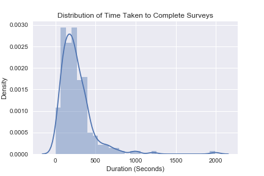

average time spent in quiz

#### First experiment.

Pie: Does the perception of the size of a slice depends on the size of the other slices?

Waffle: Does the perception of the size of an area depends on the other areas?

We fixed the size of one slice -area– (vanilla), and we changed the size of all the other slices –areas– in different ways. Intuitively, the best chart should represent the same data no matter if the size of the other slices –areas– changed.

Option 1

Sample Size Pie: 40

Sample Size Waffle: 45

ttest_ind: t = -0.364234 p = 0.71661

cohen’s d: -0.07880321382387548

Pie Exact Accuracy: 0.05

Waffle Exact Accuracy: 0.4666666666666667

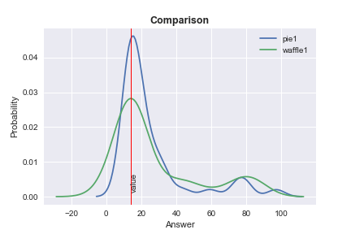

Pie Accuracy within 2 units: 0.425

Waffle Accuracy within 2 units: 0.6222222222222222 ****************************** Option 2

Sample Size Pie: 48

Sample Size Waffle: 36

ttest_ind: t = 1.26233 p = 0.210589

cohen’s d: 0.2769648261581617

Pie Exact Accuracy: 0.0625

Waffle Exact Accuracy: 0.7222222222222222

Pie Accuracy within 2 units: 0.3333333333333333

Waffle Accuracy within 2 units: 0.8055555555555556

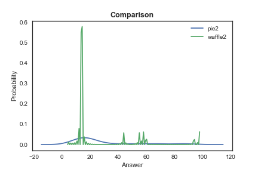

Option 3

Sample Size Pie: 32

Sample Size Waffle: 40

ttest_ind: t = 0.758422 p = 0.451261

cohen’s d: 0.18217193737817916

Pie Exact Accuracy: 0.0625

Waffle Exact Accuracy: 0.55

Pie Accuracy within 2 units: 0.40625

Waffle Accuracy within 2 units: 0.65

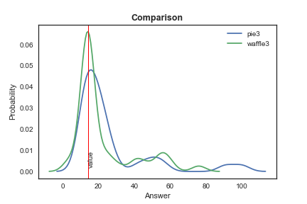

Option 4

Sample Size Pie: 45

Sample Size Waffle: 50

ttest_ind: t = 0.218429 p = 0.827576

cohen’s d: 0.044834330848297604

Pie Exact Accuracy: 0.06666666666666667

Waffle Exact Accuracy: 0.62

Pie Accuracy within 2 units: 0.4666666666666667

Waffle Accuracy within 2 units: 0.72

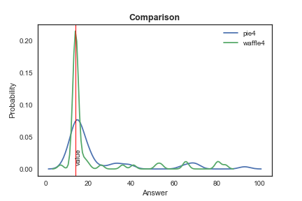

#### Second experiment.

Does the total number of observations affect the reader’s ability to estimate the size of a slice –area–?

We provided the user with a total number of individuals represented in the graph. That is to say, we mentioned that the pie –waffle– represented 1000 individuals, for example.

There are two main cases: when the total number of respondents is 1000, and when the total number of respondents is 874. The intuition behind is that 874, as a non-round number, might be more difficult to interpret.

Sample Size Pie: 72

Sample Size Waffle: 69

N = 1000

ttest_ind: t = 1.61739 p = 0.108075

cohen’s d: 0.2721334444241711

Pie Exact Accuracy: 0.013888888888888888

Waffle Exact Accuracy: 0.0

Pie Accuracy within 2 units: 0.1111111111111111

Waffle Accuracy within 2 units: 0.42028985507246375

Pie Accuracy within 5 units: 0.16666666666666666

Waffle Accuracy within 5 units: 0.42028985507246375

[figure not shown]

Sample Size Pie: 68

Sample Size Waffle: 60

N = 874

ttest_ind: t = -0.0784656 p = 0.937585

cohen’s d: -0.013906615254077681

Pie Exact Accuracy: 0.014705882352941176

Waffle Exact Accuracy: 0.18333333333333332

Pie Accuracy within 2 units: 0.058823529411764705

Waffle Accuracy within 2 units: 0.26666666666666666

Pie Accuracy within 5 units: 0.10294117647058823

Waffle Accuracy within 5 units: 0.3

[figure not shown]

## Third experiment

Does the position of the slice –area– affect the perception of its size?

If a graph is robust, it should be so not matter where the data of certain category is located. Then, for instance, if a slice is located in the top of a pie chart –or waffle chart–, it = should be perceived as being the same size as if it were in the bottom of the pie chart –waffle chart–.

For the pie chart, we fixed the location of all slices except one, which we rotate in the graph. For the waffle chart, we conducted a similar process.

To asses the perception of size, we asked about the relative size of two slices –areas–. In specific, the question was: Is the size of the orange slice bigger than the lemon slice?

Besides, we also conducted tests on whether adjacency to other slices affect its perception of size. To fully explore this, we used both apparently very different quantities, and those that were close enough to each other to be confusing.

Adjacent

Sample Size Pie: 93

Sample Size Waffle: 110

ttest_ind: t = 2.01377 p = 0.0455989

cohen’s d: 0.2866735113300187

Pie Exact Accuracy: 0.7741935483870968

Waffle Exact Accuracy: 0.8818181818181818

[figure not shown]

Opposite

Sample Size Pie: 74

Sample Size Waffle: 64

ttest_ind: t = 3.24751 p = 0.00148098

cohen’s d: 0.5472657706348194

Pie Exact Accuracy: 0.6486486486486487

Waffle Exact Accuracy: 0.875

[figure not shown]

Afterwards, assessing the size of adjacent slices with visibly different proportions was tested. The difference between pies and waffles was statistically significant in both cases, with p = 0.04, and p = 0.001 respectively. People were able to assess the size more accurately with waffles than pies for both cases. The effect size was small when slices were adjacent (Cohen’s d = 0.2866), but medium when they were not (Cohen’s d = 0.5472). It can also be inferred that it is easier to compare slices when they are adjacent, as can be seen from the statistically significant, and the small effect size. Accuracy also rises for adjacent slices. When looking at waffles specifically, there is hardly any difference, but both accuracies are still higher than those of corresponding pies.

#### Questions 5 & 6

Adjacency with similar proportions. 5 is with pie charts, 6 is with waffle charts.

Adjacent

Sample Size Pie: 65

Sample Size Waffle: 72

ttest_ind: t = 1.64543 p = 0.102319

cohen’s d: 0.28237286698646813

Pie Exact Accuracy: 0.27692307692307694

Waffle Exact Accuracy: 0.5138888888888888

Pie Accuracy within 2 units: 0.38461538461538464

Waffle Accuracy within 2 units: 0.5694444444444444

[figure not shown]

Not Adjacent

Sample Size Pie: 113

Sample Size Waffle: 108

ttest_ind: t = 1.01656 p = 0.310487

cohen’s d: 0.1368240306296562

Pie Exact Accuracy: 0.168141592920354

Waffle Exact Accuracy: 0.42592592592592593

Pie Accuracy within 2 units: 0.25663716814159293

Waffle Accuracy within 2 units: 0.5462962962962963

[figure not shown]

PIES

Adjacent vs Opposite pies

Sample Size adjacent 65

Sample Size opposite 113

ttest_ind: t = 0.179413 p = 0.857905

cohen’s d: 0.02824924659044252

Adjacent Exact Accuracy: 0.27692307692307694

Opposite Exact Accuracy: 0.168141592920354

Adjacent Accuracy within 2 units: 0.38461538461538464

Opposite Accuracy within 2 units: 0.25663716814159293

Adjacent vs Opposite waffles

Sample Size adjacent 72

Sample Size opposite 108

ttest_ind: t = -0.82105 p = 0.412859

cohen’s d: -0.12429460517179482

Adjacent Accuracy: 0.5138888888888888

Opposite Accuracy: 0.42592592592592593

Adjacent Accuracy within 2 units: 0.5694444444444444

Opposite Accuracy within 2 units: 0.5462962962962963

The next step was measuring for adjacency again, but with slices of similar size. The results show that adjacent waffles are better than adjacent pies, with a p value of 0.1, which indicates a small effect size. Accuracy is, however, higher in both cases when adjacent. When slices are not so, the difference is statistically not significant, but waffle charts retain an edge. The difference between pies with adjacent slices and not adjacent is not statistically significant, and adjacency does not seem to play too large a role in determining the proportion for waffle charts.

Adjacent

Sample Size Pie: 71

Sample Size Waffle: 77

ttest_ind: t = 2.81039 p = 0.00570223

cohen’s d: 0.4647176463950014

Pie Exact Accuracy: 0.07042253521126761

Waffle Exact Accuracy: 0.03896103896103896

Pie Accuracy within 2 units: 0.1267605633802817

Waffle Accuracy within 2 units: 0.03896103896103896

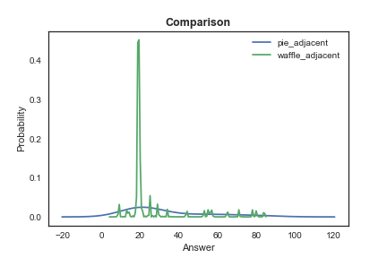

Not Adjacent

Sample Size Pie: 97

Sample Size Waffle: 97

ttest_ind: t = -1.11553 p = 0.266111

cohen’s d: -0.16018103601792638

Pie Exact Accuracy: 0.13402061855670103

Waffle Exact Accuracy: 0.0

Pie Accuracy within 2 units: 0.24742268041237114

Waffle Accuracy within 2 units: 0.020618556701030927

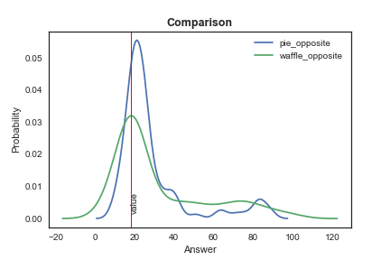

When summing slices of different sizes, the difference was very significant when comparing pie charts vs waffle charts (p=0.005). Cohen’s d value of 0.46 points to a medium effect size.However, this difference disappears when there is no adjacency; both perform poorly, even when considering for accuracy within two units.

PIES

Adjacent vs Opposite pies

Sample Size adjacent 71

Sample Size opposite 97

ttest_ind: t = 1.62227 p = 0.107009

cohen’s d: 0.2558686748598827

Adjacent Exact Accuracy: 0.07042253521126761

Opposite Exact Accuracy: 0.13402061855670103

Adjacent Accuracy within 2 units: 0.1267605633802817

Opposite Accuracy within 2 units: 0.24742268041237114

#### Sixth experiment

Does the correct of labeling of the charts affect perception of the proportions in them?

We hypothesise that mislabelling, for example, using a cream colour to represent chocolate, might cause confusion. In this experiment, we did not use evident colours in all of the slices –areas–. Then, we asked about the proportion of one slice –area–. The question was: what proportion of the respondents prefer vanilla ice cream? We had examples where only vanilla correctly labelled, examples in which only vanilla was mislabelled, and examples in which no colour was correctly labelled.

Sample Size Pie: 52

Sample Size Waffle: 56

ttest_ind: t = -0.876074 p = 0.383138

cohen’s d: -0.16758486654130628

Pie Exact Accuracy: 0.07692307692307693

Waffle Exact Accuracy: 0.6428571428571429

Pie Accuracy within 2 units: 0.5

Waffle Accuracy within 2 units: 0.7321428571428571

[figure not shown]

Vanilla is right, the rest are wrong

Sample Size Pie: 48

Sample Size Waffle: 48

ttest_ind: t = 0.900997 p = 0.369927

cohen’s d: 0.18391515053935278

Pie Exact Accuracy: 0.041666666666666664

Waffle Exact Accuracy: 0.625

Pie Accuracy within 2 units: 0.3958333333333333

Waffle Accuracy within 2 units: 0.6875

[figure not shown]

All are wrong

Sample Size Pie: 59

Sample Size Waffle: 56

ttest_ind: t = 0.481192 p = 0.631312

cohen’s d: 0.08976504305950662

Pie Exact Accuracy: 0.01694915254237288

Waffle Exact Accuracy: 0.21428571428571427

Pie Accuracy within 2 units: 0.1864406779661017

Waffle Accuracy within 2 units: 0.23214285714285715

From these results, no clear difference between pie charts and waffle pies emerges.

Pie 1 has only one colour wrongly assigned, pie 2 has all but one, and pie 3 has every single one mislabelled.

Testing between 1 and 2 throws these results:

ttest_ind: t = -1.84585 p = 0.0686893

cohen’s d: -0.3726061962862755

p1 Exact Accuracy: 0.07692307692307693

p2 Exact Accuracy: 0.041666666666666664

p1 Accuracy within 2 units: 0.5

p2 Accuracy within 2 units: 0.3958333333333333

Thus, pie 1 is assessed more correctly than pie 2, with p = 0.06, and effect size of 0.37.

Between 2 an 3, these results come up:

ttest_ind: t = -0.418012 p = 0.677073

cohen’s d: -0.08283142264328558

p3 Exact Accuracy: 0.01694915254237288

p2 Exact Accuracy: 0.041666666666666664

p3 Accuracy within 2 units: 0.1864406779661017

p2 Accuracy within 2 units: 0.3958333333333333

Between 1 and 3, these:

ttest_ind: t = 1.9517 p = 0.0535532

cohen’s d: 0.37060457019253235

p3 Exact Accuracy: 0.01694915254237288

p1 Exact Accuracy: 0.07692307692307693

p3 Accuracy within 2 units: 0.1864406779661017

p1 Accuracy within 2 units: 0.5

# Between 1+3 and 2 *This has no explanation, I do not quite understand it; we need to review before submitting

p_wrong = p1.append(p3)

p_right = p2

t, p = ttest_ind(p_wrong, p_right, equal_var= False)

cohen = cohens_d(p_wrong,p_right)

print(“ttest_ind: t = %g p = %g” % (t, p))

print(“cohen’s d:”, cohen)

print(“p_wrong Exact Accuracy:”, exact_accuracy(p_wrong,correct))

print(“p_right Exact Accuracy:”, exact_accuracy(p_right,correct))

print(“p_wrong Accuracy within 2 units:”, accuracy(p_wrong,correct,2))

print(“p_right Accuracy within 2 units:”, accuracy(p_right,correct,2))

ttest_ind: t = -1.16653 p = 0.247636

cohen’s d: -0.21660162551378484

p_wrong Exact Accuracy: 0.04504504504504504

p_right Exact Accuracy: 0.041666666666666664

p_wrong Accuracy within 2 units: 0.3333333333333333

p_right Accuracy within 2 units: 0.3958333333333333

As for waffle charts, keeping the same pattern, the following results appear:

1 & 2

ttest_ind: t = -0.0304957 p = 0.975732

cohen’s d: -0.005988255358113585

p1 Exact Accuracy: 0.6428571428571429

p2 Exact Accuracy: 0.625

p1 Accuracy within 2 units: 0.7321428571428571

p2 Accuracy within 2 units: 0.6875

2 & 3

ttest_ind: t = 0.278807 p = 0.781061

cohen’s d: 0.05542716933143575

p3 Exact Accuracy: 0.21428571428571427

p2 Exact Accuracy: 0.625

p3 Accuracy within 2 units: 0.23214285714285715

p2 Accuracy within 2 units: 0.6875

1 & 3

ttest_ind: t = 0.320592 p = 0.74919

cohen’s d: 0.060586120078777846

p3 Exact Accuracy: 0.21428571428571427

p1 Exact Accuracy: 0.6428571428571429

p3 Accuracy within 2 units: 0.23214285714285715

p1 Accuracy within 2 units: 0.7321428571428571

1+3 & 2

ttest_ind: t = 0.127743 p = 0.898666

cohen’s d: 0.02246623238251375

p_wrong Exact Accuracy: 0.42857142857142855

p_right Exact Accuracy: 0.625

p_wrong Accuracy within 2 units: 0.48214285714285715

p_right Accuracy within 2 units: 0.6875

From these, nothing noteworthy is observed.